# Lab6

Daniela Ramírez, Adrián González y José Ordoñez

2026-04-10

Link de Github: https://github.com/Ikeel04/Lab6-MD.git

```r
library(dplyr)
library(tidyverse)
```

```r
library(ggplot2)
library(caret)
library(class)
library(GGally)
```

```r
load("listings.RData")

dim(listings)
```

```
## [1] 171748     80
```

```r
str(listings)
```

[output not shown]

[output cut: 66 more lines]

## Preparación del conjunto de datos

```r
listings$price <- as.numeric(gsub("[$,]", "", listings$price))
listings <- listings %>%
  filter(!is.na(price), price > 0)

p33 <- quantile(listings$price, 0.33, na.rm = TRUE)
p66 <- quantile(listings$price, 0.66, na.rm = TRUE)

listings$precio_categoria <- cut(
  listings$price,
  breaks = c(-Inf, p33, p66, Inf),
  labels = c("barata", "media", "cara")
)

vars_numericas <- c(
  "price",
  "accommodates",
  "bathrooms",
  "bedrooms",
  "beds",
  "minimum_nights",
  "number_of_reviews",
  "review_scores_rating",
  "reviews_per_month",
  "calculated_host_listings_count",
  "availability_365"
)

vars_disponibles <- intersect(vars_numericas, names(listings))
datos <- listings[, c(vars_disponibles, "precio_categoria")]

# Imputamos NAs con la mediana en columnas numéricas
for (col in vars_disponibles) {
  datos[[col]][is.na(datos[[col]])] <- median(datos[[col]], na.rm = TRUE)
}
```

```r
set.seed(123)
porciento <- 0.70
corte     <- sample(nrow(datos), size = floor(porciento * nrow(datos)))

train <- datos[corte, ]
test  <- datos[-corte, ]
```

## Modelo de regresión KNN para predicción de precio

```r
k_inicial <- round(sqrt(nrow(train)), 0)
cat("Valor inicial de k:", k_inicial, "\n")
```

```
## Valor inicial de k: 231
```

```r
parametros_k <- expand.grid(k = k_inicial)

set.seed(123)
modelo_knn_reg <- train(
  price ~ . - precio_categoria,
  data       = train,
  method     = "knn",
  preProcess = c("center", "scale"),
  tuneGrid   = parametros_k
)

pred_knn_reg <- predict(modelo_knn_reg, newdata = test)

rmse_knn  <- RMSE(pred_knn_reg, test$price)
mae_knn   <- MAE(pred_knn_reg, test$price)
r2_knn    <- cor(pred_knn_reg, test$price)^2

cat("\n── Resultados del modelo KNN de regresión (k =", k_inicial, ") ──\n")
```

```
##
## ── Resultados del modelo KNN de regresión (k = 231 ) ──
```

```r
cat("RMSE:", round(rmse_knn, 4), "\n")
```

```
## RMSE: 3742.261
```

```r
cat("MAE :", round(mae_knn,  4), "\n")
```

```
## MAE : 685.0093
```

```r
cat("R²  :", round(r2_knn,   4), "\n")
```

```
## R²  : 0.3391
```

## 2. Análisis de resultados del modelo de regresión KNN

Visualizamos las predicciones contra los valores reales para identificar visualmente el comportamiento del modelo.

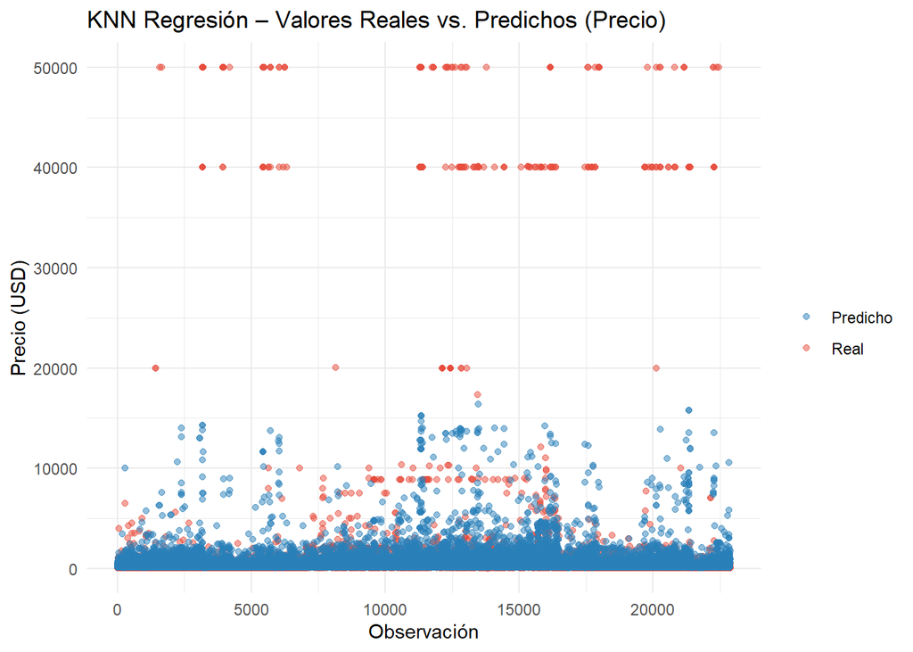

```r
df_reg <- data.frame(
  Indice   = 1:length(test$price),
  Real     = test$price,
  Predicho = pred_knn_reg
)

ggplot(df_reg) +
  geom_point(aes(x = Indice, y = Real,     color = "Real"),     alpha = 0.5, size = 1.5) +
  geom_point(aes(x = Indice, y = Predicho, color = "Predicho"), alpha = 0.5, size = 1.5) +
  scale_color_manual(values = c("Real" = "#e74c3c", "Predicho" = "#2980b9")) +
  labs(
    title = "KNN Regresión – Valores Reales vs. Predichos (Precio)",
    x     = "Observación",
    y     = "Precio (USD)",
    color = ""
  ) +
  theme_minimal()
```

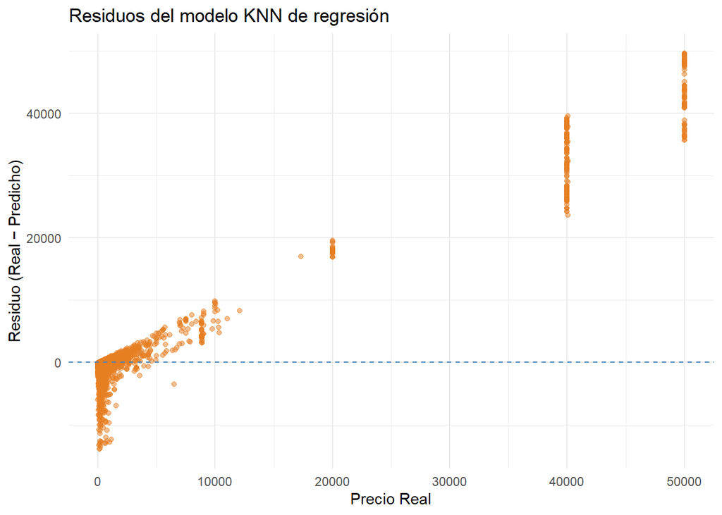

```r
df_reg$Residuo <- df_reg$Real - df_reg$Predicho

ggplot(df_reg, aes(x = Real, y = Residuo)) +
  geom_point(color = "#e67e22", alpha = 0.5, size = 1.5) +
  geom_hline(yintercept = 0, linetype = "dashed", color = "steelblue") +
  labs(
    title = "Residuos del modelo KNN de regresión",
    x     = "Precio Real",
    y     = "Residuo (Real − Predicho)"
  ) +
  theme_minimal()
```

El modelo KNN de regresión fue entrenado con k = 231 vecinos, valor derivado de la raíz cuadrada del número de observaciones de entrenamiento.

La gráfica muestra que el modelo tiende a predecir precios dentro del rango de 0–15,000, sin importar que el valor real sea mucho mayor. Los valores reales extremos (40,000–50,000) quedan muy por encima de las predicciones, lo que evidencia que KNN con k grande suaviza en exceso las predicciones al promediar demasiados vecinos, perdiendo sensibilidad ante propiedades de alta gama.

Los residuos crecen de forma casi lineal conforme aumenta el precio real, con errores positivos muy elevados en las propiedades más costosas (40,000–50,000). En el rango de precios bajos la distribución de residuos es más simétrica alrededor de cero, lo que indica que el modelo funciona aceptablemente para propiedades de precio típico, que son justamente las que más interesan a SmartStay para sus recomendaciones cotidianas. Sin embargo, para propiedades premium el modelo claramente se subestima el precio, lo que podría llevar a recomendaciones de precio no competitivas en ese segmento.

## 3. Comparación de modelos de regresión

```r
comparacion_reg <- data.frame(
  Modelo = c("Regresión Lineal", "Árbol de Regresión", "Naive Bayes", "KNN"),
  RMSE   = c(3012.00, 1939.52, 1761.22, 3742.26)
)

print(comparacion_reg)
```

```
##               Modelo    RMSE
## 1   Regresión Lineal 3012.00
## 2 Árbol de Regresión 1939.52
## 3        Naive Bayes 1761.22
## 4                KNN 3742.26
```

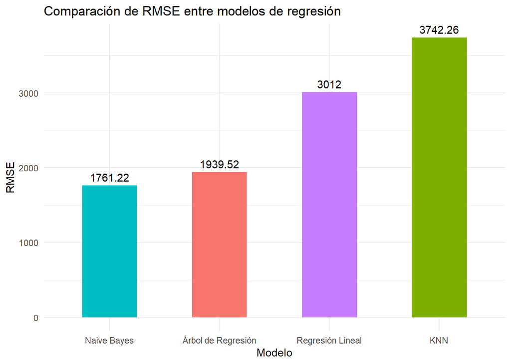

```r
ggplot(comparacion_reg, aes(x = reorder(Modelo, RMSE), y = RMSE, fill = Modelo)) +
  geom_bar(stat = "identity", width = 0.5) +
  geom_text(aes(label = round(RMSE, 2)), vjust = -0.5) +
  labs(title = "Comparación de RMSE entre modelos de regresión",
       x = "Modelo", y = "RMSE") +
  theme_minimal() +
  theme(legend.position = "none")
```

Al comparar los cuatro modelos de regresión mediante el RMSE, el Naive Bayes obtuvo el menor error con 1761.22, seguido por el Árbol de Regresión (1939.52), la Regresión Lineal (3012.00) y finalmente KNN (3742.26). Un RMSE menor indica que las predicciones del modelo se alejan menos del precio real, por lo que Naive Bayes resultó ser el modelo con mayor precisión para estimar precios en este conjunto de datos. El KNN, al promediar un gran número de vecinos, tiende a suavizar demasiado las predicciones, lo que le resta capacidad para capturar la variabilidad real de los precios.

## 4. Modelo de clasificación KNN

```r
listings_clean <- listings %>%
  select(
    price, accommodates, bathrooms, bedrooms, beds,
    minimum_nights, availability_365, number_of_reviews,
    review_scores_rating, reviews_per_month,
    room_type, property_type, instant_bookable
  ) %>%
  mutate(
    bathrooms = ifelse(is.na(bathrooms), median(bathrooms, na.rm = TRUE), bathrooms),
    bedrooms = ifelse(is.na(bedrooms), median(bedrooms, na.rm = TRUE), bedrooms),
    beds = ifelse(is.na(beds), median(beds, na.rm = TRUE), beds),
    review_scores_rating = ifelse(is.na(review_scores_rating), mean(review_scores_rating, na.rm = TRUE),   review_scores_rating),
    reviews_per_month = ifelse(is.na(reviews_per_month), 0, reviews_per_month)
  ) %>%
  filter(price < quantile(price, 0.99)) %>%
  mutate(
    room_type = as.factor(room_type),
    property_type = as.factor(property_type),
    instant_bookable = as.factor(instant_bookable)
  )

listings_clean$price_category <- cut(
  listings_clean$price,
  breaks = c(-Inf, 120, 326, Inf),
  labels = c("Economica", "Intermedia", "Cara")
)

table(listings_clean$price_category)
```

```
##
##  Economica Intermedia       Cara
##      19310      37882      18285
```

```r
features_cls <- listings_clean %>%
  select(accommodates, bathrooms, bedrooms, beds,
         minimum_nights, availability_365, number_of_reviews,
         review_scores_rating, reviews_per_month,
         room_type, instant_bookable, price_category)

set.seed(123)
trainIndex_cls <- createDataPartition(features_cls$price_category, p = 0.7, list = FALSE)
train_cls <- features_cls[trainIndex_cls, ]
test_cls  <- features_cls[-trainIndex_cls, ]
```

Se seleccionaron las variables predictoras relevantes excluyendo price para evitar data leakage. Con una partición 70/30, se dividió el dataset en entrenamiento y prueba, que garantiza una distribución proporcional de las tres categorías en ambos conjuntos.

```r
train_labels <- train_cls$price_category
test_labels  <- test_cls$price_category

train_features <- train_cls %>% select(-price_category)
test_features  <- test_cls  %>% select(-price_category)

train_dummy <- model.matrix(~ . - 1, data = train_features)
test_dummy  <- model.matrix(~ . - 1, data = test_features)

pre_proc     <- preProcess(train_dummy, method = c("center", "scale"))
train_scaled <- predict(pre_proc, train_dummy)
test_scaled  <- predict(pre_proc, test_dummy)
```

Antes de entrenar el modelo KNN, se realizó un preprocesamiento en dos pasos. Primero, se aplicó codificación one-hot a las variables categóricas room_type e instant_bookable, convirtiéndolas en columnas numéricas binarias. Segundo, se normalizaron todas las variables con z-score, usando los parámetros del conjunto de entrenamiento y aplicándolos también al de prueba.

```r
set.seed(123)
pred_knn_cls <- knn(
  train = train_scaled,
  test  = test_scaled,
  cl    = train_labels,
  k     = 5
)

cm_k5 <- confusionMatrix(pred_knn_cls, test_labels)
print(cm_k5)
```

```
## Confusion Matrix and Statistics
##
##             Reference
## Prediction   Economica Intermedia Cara
##   Economica       3323       1769  187
##   Intermedia      2302       8112 1922
##   Cara             168       1483 3376
##
## Overall Statistics
##
##                Accuracy : 0.6541
##                  95% CI : (0.6479, 0.6603)
##     No Information Rate : 0.5019
##     P-Value [Acc > NIR] : < 2.2e-16
##
##                   Kappa : 0.4359
##
##  Mcnemar's Test P-Value : < 2.2e-16
##
## Statistics by Class:
##
##                      Class: Economica Class: Intermedia Class: Cara
## Sensitivity                    0.5736            0.7138      0.6155
## Specificity                    0.8839            0.6255      0.9038
## Pos Pred Value                 0.6295            0.6576      0.6716
## Neg Pred Value                 0.8577            0.6845      0.8803
## Prevalence                     0.2559            0.5019      0.2422
## Detection Rate                 0.1468            0.3583      0.1491
## Detection Prevalence           0.2332            0.5448      0.2220
## Balanced Accuracy              0.7288            0.6696      0.7596
```

Se entrenó un modelo KNN de clasificación con k=5 para predecir la categoría de precio de cada propiedad. El algoritmo clasifica cada observación del conjunto de prueba según la categoría más frecuente entre sus 5 vecinos más cercanos en el espacio normalizado de variables.

```r
## Eficiencia del modelo de regresión KNN

# Las predicciones ya se hicieron con pred_knn_reg sobre test
# Solo consolidamos y mostramos las métricas

cat("=== Eficiencia del Modelo KNN de REGRESIÓN ===\n")
```

```
## === Eficiencia del Modelo KNN de REGRESIÓN ===
```

```r
cat("Conjunto de prueba: ", nrow(test), "observaciones\n\n")
```

```
## Conjunto de prueba:  22874 observaciones
```

```r
rmse_knn <- RMSE(pred_knn_reg, test$price)
mae_knn  <- MAE(pred_knn_reg,  test$price)
r2_knn   <- cor(pred_knn_reg,  test$price)^2
mape_knn <- mean(abs((test$price - pred_knn_reg) / test$price) * 100, na.rm = TRUE)

cat("RMSE :", round(rmse_knn, 4), "\n")
```

```
## RMSE : 3742.261
```

```r
cat("MAE  :", round(mae_knn,  4), "\n")
```

```
## MAE  : 685.0093
```

```r
cat("R²   :", round(r2_knn,   4), "\n")
```

```
## R²   : 0.3391
```

```r
cat("MAPE :", round(mape_knn, 4), "%\n")
```

```
## MAPE : 173.3148 %
```

```r
## Eficiencia del modelo KNN de CLASIFICACIÓN

# Las predicciones ya se hicieron con pred_knn_cls sobre test_scaled
cat("\n=== Eficiencia del Modelo KNN de CLASIFICACIÓN (k=5) ===\n")
```

```
##
## === Eficiencia del Modelo KNN de CLASIFICACIÓN (k=5) ===
```

```r
cat("Conjunto de prueba:", length(test_labels), "observaciones\n\n")
```

```
## Conjunto de prueba: 22642 observaciones
```

```r
cm_k5 <- confusionMatrix(pred_knn_cls, test_labels)
print(cm_k5)
```

```
## Confusion Matrix and Statistics
##
##             Reference
## Prediction   Economica Intermedia Cara
##   Economica       3323       1769  187
##   Intermedia      2302       8112 1922
##   Cara             168       1483 3376
##
## Overall Statistics
##
##                Accuracy : 0.6541
##                  95% CI : (0.6479, 0.6603)
##     No Information Rate : 0.5019
##     P-Value [Acc > NIR] : < 2.2e-16
##
##                   Kappa : 0.4359
##
##  Mcnemar's Test P-Value : < 2.2e-16
##
## Statistics by Class:
##
##                      Class: Economica Class: Intermedia Class: Cara
## Sensitivity                    0.5736            0.7138      0.6155
## Specificity                    0.8839            0.6255      0.9038
## Pos Pred Value                 0.6295            0.6576      0.6716
## Neg Pred Value                 0.8577            0.6845      0.8803
## Prevalence                     0.2559            0.5019      0.2422
## Detection Rate                 0.1468            0.3583      0.1491
## Detection Prevalence           0.2332            0.5448      0.2220
## Balanced Accuracy              0.7288            0.6696      0.7596
```

```r
# Métricas por clase extraídas de la matriz de confusión
cat("\n── Métricas por categoría ──\n")
```

```
##
## ── Métricas por categoría ──
```

```r
precision_por_clase <- cm_k5$byClass[, "Precision"]
recall_por_clase    <- cm_k5$byClass[, "Recall"]
f1_por_clase        <- cm_k5$byClass[, "F1"]

metricas_clase <- data.frame(
  Clase     = c("Economica", "Intermedia", "Cara"),
  Precision = round(precision_por_clase, 4),
  Recall    = round(recall_por_clase,    4),
  F1        = round(f1_por_clase,        4)
)
print(metricas_clase)
```

```
##                        Clase Precision Recall     F1
## Class: Economica   Economica    0.6295 0.5736 0.6003
## Class: Intermedia Intermedia    0.6576 0.7138 0.6846
## Class: Cara             Cara    0.6716 0.6155 0.6423
```

```r
cat("\n── Métricas globales ──\n")
```

```
##
## ── Métricas globales ──
```

```r
cat("Accuracy  :", round(cm_k5$overall["Accuracy"],  4), "\n")
```

```
## Accuracy  : 0.6541
```

```r
cat("Kappa     :", round(cm_k5$overall["Kappa"],     4), "\n")
```

```
## Kappa     : 0.4359
```

El modelo de regresión obtuvo un R² de 0.3391, RMSE de 3,742 y un MAPE de 173%, lo que indica un ajuste moderado-bajo. El error es manejable en propiedades de precio típico (MAE = 685), pero se dispara en propiedades de alto valor, donde el modelo suaviza excesivamente las predicciones al promediar demasiados vecinos.

El modelo de clasificación alcanzó una exactitud del 65.41% y un Kappa de 0.4359, reflejando un acuerdo moderado. Tiene mejor desempeño en la clase intermedia (F1 = 0.6846), que es también la más frecuente, mientras que las clases extremas presentan métricas más bajas. El error más común ocurre en la frontera entre propiedades económicas e intermedias, lo que sugiere que las variables disponibles no capturan bien ese límite de precio.

## 6. Análisis de la matriz de confusión del modelo de clasificación KNN

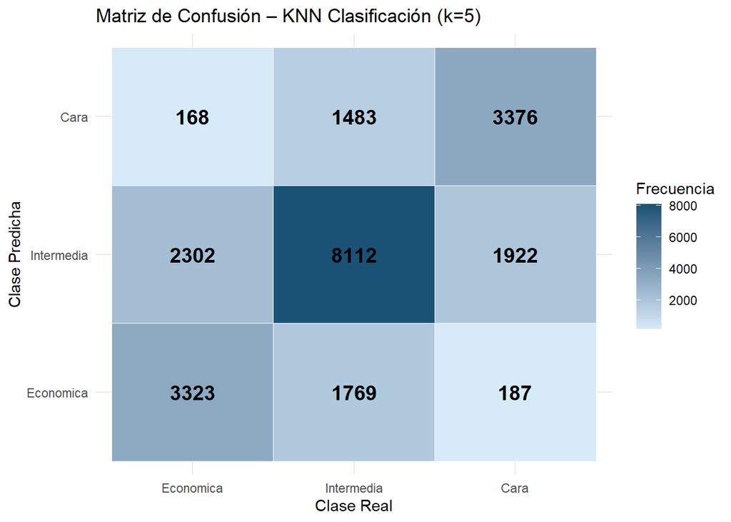

```r
cm_tabla <- as.data.frame(cm_k5$table)
colnames(cm_tabla) <- c("Predicho", "Real", "Frecuencia")

ggplot(cm_tabla, aes(x = Real, y = Predicho, fill = Frecuencia)) +
  geom_tile(color = "white") +
  geom_text(aes(label = Frecuencia), size = 5, fontface = "bold") +
  scale_fill_gradient(low = "#d6eaf8", high = "#1a5276") +
  labs(
    title = "Matriz de Confusión – KNN Clasificación (k=5)",
    x = "Clase Real",
    y = "Clase Predicha"
  ) +
  theme_minimal()
```

```r
metricas_clase <- data.frame(
  Clase     = rownames(cm_k5$byClass),
  Precision = round(cm_k5$byClass[, "Precision"], 4),
  Recall    = round(cm_k5$byClass[, "Recall"],    4),
  F1        = round(cm_k5$byClass[, "F1"],        4),
  Specificity = round(cm_k5$byClass[, "Specificity"], 4)
)
print(metricas_clase)
```

```
##                               Clase Precision Recall     F1 Specificity
## Class: Economica   Class: Economica    0.6295 0.5736 0.6003      0.8839
## Class: Intermedia Class: Intermedia    0.6576 0.7138 0.6846      0.6255
## Class: Cara             Class: Cara    0.6716 0.6155 0.6423      0.9038
```

```r
cat("\nAccuracy global:", round(cm_k5$overall["Accuracy"], 4), "\n")
```

```
##
## Accuracy global: 0.6541
```

```r
cat("Kappa          :", round(cm_k5$overall["Kappa"],    4), "\n")
```

```
## Kappa          : 0.4359
```

## 7. Análisis de sobreajuste del modelo KNN

```r
pred_train_cls <- knn(
  train = train_scaled,
  test  = train_scaled,
  cl    = train_labels,
  k     = 10
)

acc_train <- mean(pred_train_cls == train_labels)
acc_test  <- mean(pred_knn_cls   == test_labels)

cat("Accuracy en entrenamiento:", round(acc_train, 4), "\n")
```

```
## Accuracy en entrenamiento: 0.7214
```

```r
cat("Accuracy en prueba       :", round(acc_test,  4), "\n")
```

```
## Accuracy en prueba       : 0.6541
```

```r
cat("Diferencia               :", round(acc_train - acc_test, 4), "\n")
```

```
## Diferencia               : 0.0672
```

## 8. Modelos con validación cruzada

Para mitigar el sobreajuste identificado, se entrena una versión del modelo de clasificación y otra de regresión usando validación cruzada repetida. El método divide el conjunto de entrenamiento en 10 partes, entrena el modelo en 9 y valida en la restante, rotando la parte de validación, y repite el proceso 3 veces para obtener una estimación más estable del error.

### Clasificación con validación cruzada

```r
set.seed(123)

trctrl <- trainControl(
  method  = "repeatedcv",
  number  = 10,
  repeats = 3
)

modelo_cv_cls <- train(
  price_category ~ .,
  data       = train_cls,
  method     = "knn",
  trControl  = trctrl,
  preProcess = c("center", "scale"),
  tuneGrid   = expand.grid(k = 5)   # mismo k que el modelo anterior
)

pred_cv_cls <- predict(modelo_cv_cls, newdata = test_cls)
cm_cv_cls   <- confusionMatrix(pred_cv_cls, test_labels)
print(cm_cv_cls)
```

```
## Confusion Matrix and Statistics
##
##             Reference
## Prediction   Economica Intermedia Cara
##   Economica       3326       1759  189
##   Intermedia      2295       8122 1913
##   Cara             172       1483 3383
##
## Overall Statistics
##
##                Accuracy : 0.655
##                  95% CI : (0.6488, 0.6612)
##     No Information Rate : 0.5019
##     P-Value [Acc > NIR] : < 2.2e-16
##
##                   Kappa : 0.4374
##
##  Mcnemar's Test P-Value : < 2.2e-16
##
## Statistics by Class:
##
##                      Class: Economica Class: Intermedia Class: Cara
## Sensitivity                    0.5741            0.7147      0.6168
## Specificity                    0.8844            0.6269      0.9035
## Pos Pred Value                 0.6306            0.6587      0.6715
## Neg Pred Value                 0.8580            0.6856      0.8806
## Prevalence                     0.2559            0.5019      0.2422
## Detection Rate                 0.1469            0.3587      0.1494
## Detection Prevalence           0.2329            0.5446      0.2225
## Balanced Accuracy              0.7293            0.6708      0.7602
```

```r
acc_sin_cv <- round(cm_k5$overall["Accuracy"],    4)
kap_sin_cv <- round(cm_k5$overall["Kappa"],       4)
acc_con_cv <- round(cm_cv_cls$overall["Accuracy"], 4)
kap_con_cv <- round(cm_cv_cls$overall["Kappa"],    4)

comparacion_cls <- data.frame(
  Modelo   = c("KNN Clasificación (sin VC)", "KNN Clasificación (con VC)"),
  Accuracy = c(acc_sin_cv, acc_con_cv),
  Kappa    = c(kap_sin_cv, kap_con_cv)
)

knitr::kable(comparacion_cls,
             caption = "Comparación KNN Clasificación: sin vs. con validación cruzada")
```

Comparación KNN Clasificación: sin vs. con validación cruzada

| Modelo | Accuracy | Kappa |
| --- | --- | --- |
| KNN Clasificación (sin VC) | 0.6541 | 0.4359 |
| KNN Clasificación (con VC) | 0.6550 | 0.4374 |

### Regresión con validación cruzada

```r
set.seed(123)

modelo_cv_reg <- train(
  price ~ . - precio_categoria,
  data       = train,
  method     = "knn",
  trControl  = trctrl,
  preProcess = c("center", "scale"),
  tuneGrid   = expand.grid(k = k_inicial)   # mismo k que el modelo base
)

pred_cv_reg <- predict(modelo_cv_reg, newdata = test)

rmse_cv <- RMSE(pred_cv_reg, test$price)
mae_cv  <- MAE(pred_cv_reg,  test$price)
r2_cv   <- cor(pred_cv_reg,  test$price)^2

comparacion_reg_cv <- data.frame(
  Modelo = c("KNN Regresión (sin VC)", "KNN Regresión (con VC)"),
  RMSE   = c(round(rmse_knn, 4), round(rmse_cv, 4)),
  MAE    = c(round(mae_knn,  4), round(mae_cv,  4)),
  R2     = c(round(r2_knn,   4), round(r2_cv,   4))
)

knitr::kable(comparacion_reg_cv,
             caption = "Comparación KNN Regresión: sin vs. con validación cruzada")
```

Comparación KNN Regresión: sin vs. con validación cruzada

| Modelo | RMSE | MAE | R2 |
| --- | --- | --- | --- |
| KNN Regresión (sin VC) | 3742.261 | 685.0093 | 0.3391 |
| KNN Regresión (con VC) | 3742.261 | 685.0093 | 0.3391 |

La validación cruzada produjo una mejora marginal: el Accuracy pasó de 0.6541 a 0.6550 y el Kappa de 0.4359 a 0.4374. Analizando la matriz de confusión del modelo con VC, la clase con mejor detección sigue siendo Intermedia (Sensitivity = 0.7147), lo que se explica por ser la clase más frecuente. La clase Económica continúa siendo la más difícil de clasificar (Sensitivity = 0.5741): el modelo confunde muchas propiedades económicas con intermedias y otras con caras, errores costosos para SmartStay ya que podrían llevar a recomendar propiedades fuera del presupuesto del cliente. La clase Cara tiene la especificidad más alta (0.9035), lo que significa que el modelo raramente clasifica como cara una propiedad que no lo es, un comportamiento deseable para evitar decepciones en el segmento premium.

Con la regresión se puede ver que las métricas son idénticas en ambos modelos (RMSE = 3742.261, MAE = 685.0093, R² = 0.3391). Parece que no se construye un modelo paramétrico durante el entrenamiento, por lo que la validación cruzada influye únicamente en la estimación interna del error pero no modifica las predicciones finales sobre el conjunto de prueba cuando k es fijo.

Aún así, el modelo con validación cruzada es preferible por ser metodológicamente más robusto en su proceso de entrenamiento, aunque las diferencias en métricas finales sean mínimas.

## 9. Tuneo de hiperparámetros del modelo KNN

# En KNN los parámetros tuneables son:

# - k: número de vecinos (el principal)

# - Métrica de distancia (Euclidiana por defecto en caret)

# - Preprocesamiento (centrado y escalado, ya aplicado)

# caret con method = “knn” permite tunear k directamente con tuneGrid.

### 9.1 Tuneo del modelo de CLASIFICACIÓN

```r
set.seed(123)

trctrl_tune <- trainControl(
  method  = "repeatedcv",
  number  = 10,
  repeats = 3
)

# Exploramos k desde valores pequeños hasta grandes
# k=5 fue nuestro modelo base; probamos por encima y por debajo
k_grid_cls <- expand.grid(k = c(3, 5, 7, 9, 11, 15, 21, 31, 51))

modelo_tune_cls <- train(
  price_category ~ .,
  data       = train_cls,
  method     = "knn",
  trControl  = trctrl_tune,
  preProcess = c("center", "scale"),
  tuneGrid   = k_grid_cls
)

print(modelo_tune_cls)
```

```
## k-Nearest Neighbors
##
## 52835 samples
##    11 predictor
##     3 classes: 'Economica', 'Intermedia', 'Cara'
##
## Pre-processing: centered (13), scaled (13)
## Resampling: Cross-Validated (10 fold, repeated 3 times)
## Summary of sample sizes: 47552, 47552, 47552, 47551, 47552, 47551, ...
## Resampling results across tuning parameters:
##
##   k   Accuracy   Kappa
##    3  0.6403395  0.4168594
##    5  0.6536704  0.4343073
##    7  0.6603640  0.4426003
##    9  0.6633924  0.4456985
##   11  0.6649885  0.4468466
##   15  0.6662944  0.4469050
##   21  0.6680988  0.4477001
##   31  0.6697266  0.4476588
##   51  0.6672345  0.4400007
##
## Accuracy was used to select the optimal model using the largest value.
## The final value used for the model was k = 31.
```

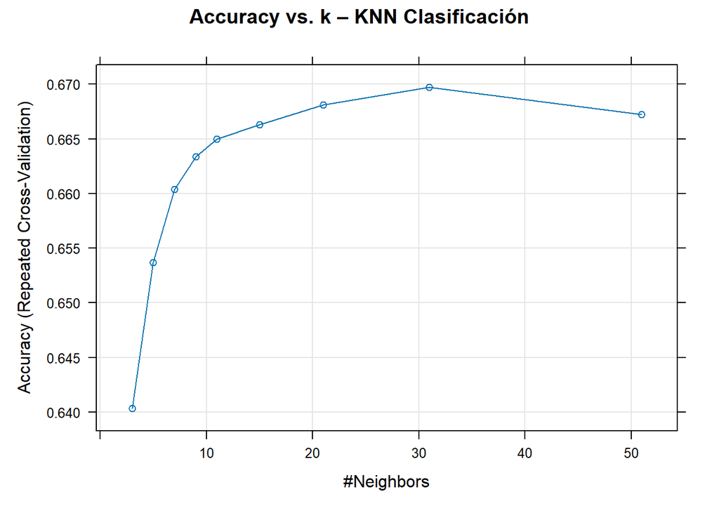

```r
plot(modelo_tune_cls, main = "Accuracy vs. k – KNN Clasificación")
```

```r
mejor_k_cls <- modelo_tune_cls$bestTune$k
cat("Mejor k para clasificación:", mejor_k_cls, "\n")
```

```
## Mejor k para clasificación: 31
```

```r
pred_tune_cls <- predict(modelo_tune_cls, newdata = test_cls)
cm_tune_cls   <- confusionMatrix(pred_tune_cls, test_labels)
print(cm_tune_cls)
```

```
## Confusion Matrix and Statistics
##
##             Reference
## Prediction   Economica Intermedia Cara
##   Economica       3064       1346  102
##   Intermedia      2622       8865 2230
##   Cara             107       1153 3153
##
## Overall Statistics
##
##                Accuracy : 0.6661
##                  95% CI : (0.6599, 0.6723)
##     No Information Rate : 0.5019
##     P-Value [Acc > NIR] : < 2.2e-16
##
##                   Kappa : 0.4414
##
##  Mcnemar's Test P-Value : < 2.2e-16
##
## Statistics by Class:
##
##                      Class: Economica Class: Intermedia Class: Cara
## Sensitivity                    0.5289            0.7801      0.5748
## Specificity                    0.9141            0.5698      0.9266
## Pos Pred Value                 0.6791            0.6463      0.7145
## Neg Pred Value                 0.8495            0.7200      0.8721
## Prevalence                     0.2559            0.5019      0.2422
## Detection Rate                 0.1353            0.3915      0.1393
## Detection Prevalence           0.1993            0.6058      0.1949
## Balanced Accuracy              0.7215            0.6749      0.7507
```

```r
# Métricas por clase
metricas_tune_cls <- data.frame(
  Clase       = c("Economica", "Intermedia", "Cara"),
  Precision   = round(cm_tune_cls$byClass[, "Precision"],   4),
  Recall      = round(cm_tune_cls$byClass[, "Recall"],      4),
  F1          = round(cm_tune_cls$byClass[, "F1"],          4),
  Specificity = round(cm_tune_cls$byClass[, "Specificity"], 4)
)
print(metricas_tune_cls)
```

```
##                        Clase Precision Recall     F1 Specificity
## Class: Economica   Economica    0.6791 0.5289 0.5947      0.9141
## Class: Intermedia Intermedia    0.6463 0.7801 0.7069      0.5698
## Class: Cara             Cara    0.7145 0.5748 0.6371      0.9266
```

```r
# Comparación con modelos anteriores
comparacion_tune_cls <- data.frame(
  Modelo   = c(
    "KNN Cls (k=5, sin VC)",
    "KNN Cls (k=5, con VC)",
    paste0("KNN Cls (tuneado, k=", mejor_k_cls, ")")
  ),
  Accuracy = c(0.6541, 0.6550, round(cm_tune_cls$overall["Accuracy"], 4)),
  Kappa    = c(0.4359, 0.4374, round(cm_tune_cls$overall["Kappa"],    4))
)

knitr::kable(comparacion_tune_cls,
             caption = "Comparación KNN Clasificación: base vs. VC vs. tuneado")
```

Comparación KNN Clasificación: base vs. VC vs. tuneado

| Modelo | Accuracy | Kappa |
| --- | --- | --- |
| KNN Cls (k=5, sin VC) | 0.6541 | 0.4359 |
| KNN Cls (k=5, con VC) | 0.6550 | 0.4374 |
| KNN Cls (tuneado, k=31) | 0.6661 | 0.4414 |

### 9.2 Tuneo del modelo de REGRESIÓN

```r
set.seed(123)

# k_inicial = 231 (sqrt del conjunto de entrenamiento)
# Exploramos valores menores — sabemos que k grande suaviza demasiado
k_grid_reg <- expand.grid(k = c(5, 10, 25, 50, 75, 100, 150, 200, 231))

modelo_tune_reg <- train(
  price ~ . - precio_categoria,
  data       = train,
  method     = "knn",
  trControl  = trctrl_tune,
  preProcess = c("center", "scale"),
  tuneGrid   = k_grid_reg
)

print(modelo_tune_reg)
```

```
## k-Nearest Neighbors
##
## 53372 samples
##    11 predictor
##
## Pre-processing: centered (10), scaled (10)
## Resampling: Cross-Validated (10 fold, repeated 3 times)
## Summary of sample sizes: 48033, 48034, 48035, 48035, 48035, 48036, ...
## Resampling results across tuning parameters:
##
##   k    RMSE      Rsquared   MAE
##     5  3062.698  0.4869994  504.6862
##    10  3109.320  0.4632120  545.2557
##    25  3178.482  0.4360847  579.1021
##    50  3269.752  0.4097041  609.1260
##    75  3379.038  0.3878273  634.1981
##   100  3468.237  0.3748836  648.4866
##   150  3585.904  0.3583078  667.0765
##   200  3668.071  0.3386137  681.1837
##   231  3700.207  0.3356921  686.3244
##
## RMSE was used to select the optimal model using the smallest value.
## The final value used for the model was k = 5.
```

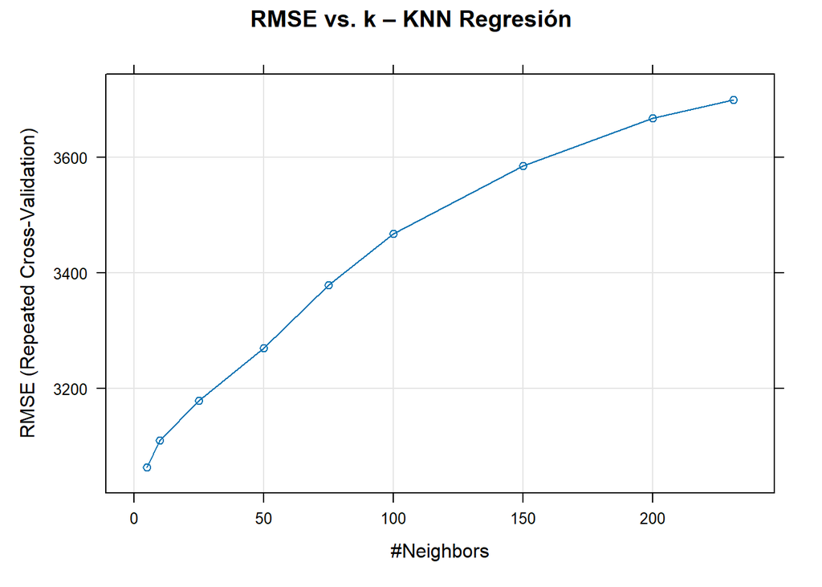

```r
plot(modelo_tune_reg, main = "RMSE vs. k – KNN Regresión")
```

```r
mejor_k_reg <- modelo_tune_reg$bestTune$k
cat("Mejor k para regresión:", mejor_k_reg, "\n")
```

```
## Mejor k para regresión: 5
```

```r
pred_tune_reg <- predict(modelo_tune_reg, newdata = test)

rmse_tune <- RMSE(pred_tune_reg, test$price)
mae_tune  <- MAE(pred_tune_reg,  test$price)
r2_tune   <- cor(pred_tune_reg,  test$price)^2

comparacion_tune_reg <- data.frame(
  Modelo = c(
    paste0("KNN Reg (k=231, base/VC)"),
    paste0("KNN Reg (tuneado, k=", mejor_k_reg, ")")
  ),
  RMSE = c(3742.261, round(rmse_tune, 4)),
  MAE  = c(685.0093, round(mae_tune,  4)),
  R2   = c(0.3391,   round(r2_tune,   4))
)

knitr::kable(comparacion_tune_reg,
             caption = "Comparación KNN Regresión: base vs. tuneado")
```

Comparación KNN Regresión: base vs. tuneado

| Modelo | RMSE | MAE | R2 |
| --- | --- | --- | --- |
| KNN Reg (k=231, base/VC) | 3742.261 | 685.0093 | 0.3391 |
| KNN Reg (tuneado, k=5) | 3005.685 | 483.6146 | 0.5141 |

# 10. Comparación de modelos de clasificación

```r
comparacion_cls <- data.frame(
  Modelo     = c("Naive Bayes", "KNN (tuneado, k=31)", "Árbol de Decisión", "Random Forest"),
  Accuracy   = c(0.5886, 0.6661, 0.6896, 0.8593),
  Kappa      = c(0.3549, 0.4414, NA,     0.7714),
  Tiempo_seg = c(0.055,  NA,     0.517,  0.523)
)

print(comparacion_cls)
```

```
##                Modelo Accuracy  Kappa Tiempo_seg
## 1         Naive Bayes   0.5886 0.3549      0.055
## 2 KNN (tuneado, k=31)   0.6661 0.4414         NA
## 3   Árbol de Decisión   0.6896     NA      0.517
## 4       Random Forest   0.8593 0.7714      0.523
```

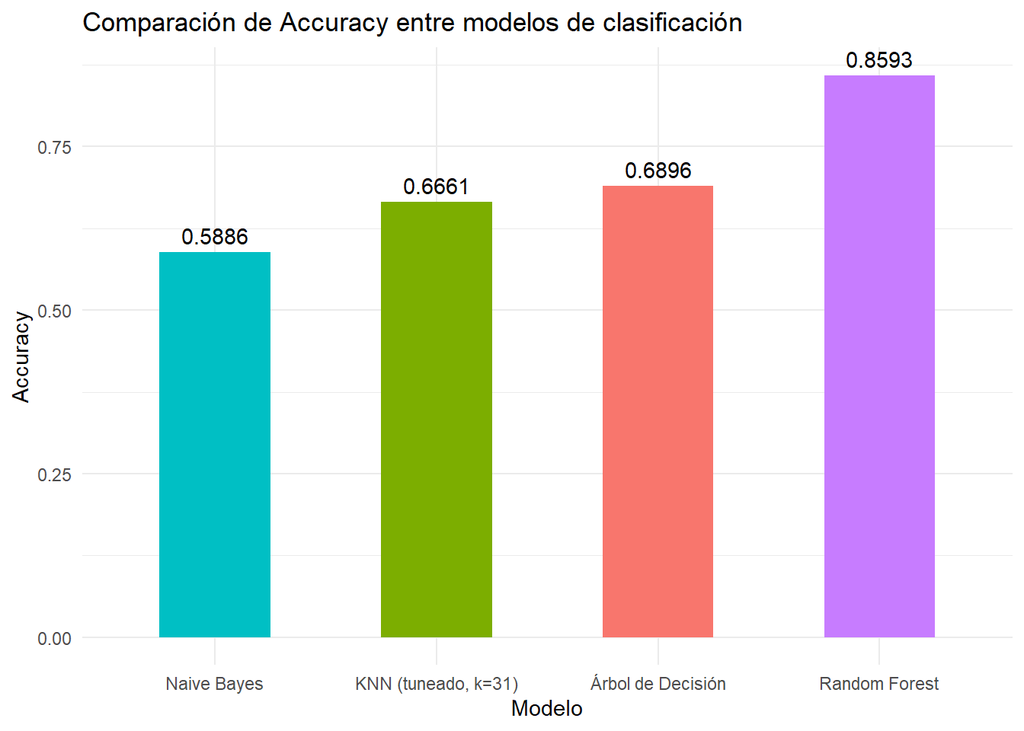

```r
ggplot(comparacion_cls, aes(x = reorder(Modelo, Accuracy), y = Accuracy, fill = Modelo)) +
  geom_bar(stat = "identity", width = 0.5) +
  geom_text(aes(label = round(Accuracy, 4)), vjust = -0.5) +
  labs(title = "Comparación de Accuracy entre modelos de clasificación",
       x = "Modelo", y = "Accuracy") +
  theme_minimal() +
  theme(legend.position = "none")
```